# Linear and Nonlinear Models (31010) Week 4 Workshop: Binomial Regression

© Yuri Balasanov, iLykei 2016

# 1 Binomial regression

**Recall:**

**1. $Y_i, i=1, \ldots ,n$ are independent variables with binomial distribution $B(n_i,p_i), \sum_{i=1}^n n_i = N$.**  
**2. $P(Y_i=y_i) = {{n_i}\choose{y_i}} p_i^{y_i} (1-p_i)^{n_i-y_i}$.**  
**3. All Bernoulli trials of group $i$ have the same linear relationships with $q$ covariates with linear predictors**

$$\eta_i = \beta_0 +\beta_1 x_1 + \ldots + \beta_q x_q,$$
where $\eta_i = g(p_i).$
4. The function $g(p_i)$ is one of several links:
$$g(p)=\ln(\frac{p}{1-p}),$$
$$g(p)=\Phi^{-1}(p),$$
$$g(p)=\ln(-\ln(1-p)).$$
**5. In many cases we have $n_i = 1, i=1,2, \ldots,n$.**
**In such cases the results are not going to be very reliable, of course.**

# 2 Interpreting odds

```r
library(faraway)
```

**Remember notations:** $Odds = \frac{p}{1-p}$.  
Odds ratio for event $A$ is the ratio

$$\frac{P(A)}{P(!A)}.$$
Odds ratio against $A$ is
$$\frac{P(!A)}{P(A)}.$$
Odds ratio for 6 on die roll is 1 to 5 ($\frac{1}{5}$). If such event occurs we expect to make $5 on $1 bet.

If you bet for, there will be 2 betting against 8 ($2 against $8). In case of $A$ the payoff is $\frac{8}{2} = 4$.  
In case of $!A$ there is loss of $1.  
This payoff is equivalent to $P(A)=\frac{1}{5}> \frac{1}{6}.$

**Random variable $X$ has normal distribution with mean $\mu=0.1$ and standard deviation $\sigma=1.5$.**  
**What are the odds of the event ($X>=0$)?**

(Skipped Code)

```
## [1] 0.5265765
```

```
## [1] 1.112274
```

Let the probability of event $A$ be $P(A)=0.53$. If you bet **on** this event, how much you expect to make on $1 bet if $A$ occurs?  
How much you expect to make by betting $1 **against** if $A$ does not occur?

**Make decision whether you want to bet on or against the event ($X>=0$) if you play once.**  
**How much money you are ready to bet, how much you put at risk and how much you expect to win?**

# 3 Example with Baby Food on Page 32

Earlier we talked about using logistic regression to solve classification problem.  
Now we use it to analyze a contingency table.

Contingency tables will be defined in more general case in one of the future lectures.

In this type of experiment we compare odds of an event under 2 or more different conditions.

Use the data `babyfood` from package `faraway` representing the study of relationship between baby food type and respiratory diseases in the first year of life.

```r
data(babyfood)
babyfood
```

```
##   disease nondisease  sex   food
## 1      77        381  Boy Bottle
## 2      19        128  Boy  Suppl
## 3      47        447  Boy Breast
## 4      48        336 Girl Bottle
## 5      16        111 Girl  Suppl
## 6      31        433 Girl Breast
```

Create contingency table with the data

```r
xtabs(disease/(disease+nondisease)~sex+food,babyfood)
```

```
##       food
## sex        Bottle     Breast      Suppl
##   Boy  0.16812227 0.09514170 0.12925170
##   Girl 0.12500000 0.06681034 0.12598425
```

In case of samples from binomial distributions we conducted pair-wise comparisons using `prop.test()`.  
**Example.** If in the first group of 10 Bernoulli trials we observed 3 successes and 7 failures and in the second group of 47 trials we observed 15 successes and 32 failures, then testing of $H_0: p_1=p_2$ is done by

```r
prop.test(rbind(c(3,7),c(15,32)))
```

```
##
##  2-sample test for equality of proportions with continuity
##  correction
##
## data:  rbind(c(3, 7), c(15, 32))
## X-squared = 2.9716e-31, df = 1, p-value = 1
## alternative hypothesis: two.sided
## 95 percent confidence interval:
##  -0.3520345  0.3137366
## sample estimates:
##    prop 1    prop 2
## 0.3000000 0.3191489
```

Compare the contingency table proportions with the results from `prop.test()`

```r
babyfood[c(1,2),]
```

```
##   disease nondisease sex   food
## 1      77        381 Boy Bottle
## 2      19        128 Boy  Suppl
```

```r
babyfood[1,1]/(babyfood[1,1]+babyfood[1,2])
```

```
## [1] 0.1681223
```

```r
prop.test(as.matrix(babyfood[c(1,2),1:2]))
```

```
##
##  2-sample test for equality of proportions with continuity
##  correction
##
## data:  as.matrix(babyfood[c(1, 2), 1:2])
## X-squared = 0.98514, df = 1, p-value = 0.3209
## alternative hypothesis: two.sided
## 95 percent confidence interval:
##  -0.0297640  0.1075051
## sample estimates:
##    prop 1    prop 2
## 0.1681223 0.1292517
```

```r
prop.test(as.matrix(babyfood[c(1,3),1:2]))
```

```
##
##  2-sample test for equality of proportions with continuity
##  correction
##
## data:  as.matrix(babyfood[c(1, 3), 1:2])
## X-squared = 10.539, df = 1, p-value = 0.001169
## alternative hypothesis: two.sided
## 95 percent confidence interval:
##  0.02795236 0.11800878
## sample estimates:
##    prop 1    prop 2
## 0.1681223 0.0951417
```

```r
prop.test(as.matrix(babyfood[c(4,5),1:2]))
```

```
##
##  2-sample test for equality of proportions with continuity
##  correction
##
## data:  as.matrix(babyfood[c(4, 5), 1:2])
## X-squared = 2.7488e-31, df = 1, p-value = 1
## alternative hypothesis: two.sided
## 95 percent confidence interval:
##  -0.06848773  0.06651923
## sample estimates:
##    prop 1    prop 2
## 0.1250000 0.1259843
```

```r
prop.test(as.matrix(babyfood[c(4,6),1:2]))
```

```
##
##  2-sample test for equality of proportions with continuity
##  correction
##
## data:  as.matrix(babyfood[c(4, 6), 1:2])
## X-squared = 7.7467, df = 1, p-value = 0.005381
## alternative hypothesis: two.sided
## 95 percent confidence interval:
##  0.01568101 0.10069830
## sample estimates:
##     prop 1     prop 2
## 0.12500000 0.06681034
```

```r
prop.test(as.matrix(rbind(babyfood[1,1:2]+babyfood[4,1:2],babyfood[3,1:2]+babyfood[6,1:2])))
```

```
##
##  2-sample test for equality of proportions with continuity
##  correction
##
## data:  as.matrix(rbind(babyfood[1, 1:2] + babyfood[4, 1:2], babyfood[3,     1:2] + babyfood[6, 1:2]))
## X-squared = 19.462, df = 1, p-value = 1.026e-05
## alternative hypothesis: two.sided
## 95 percent confidence interval:
##  0.03631237 0.09776049
## sample estimates:
##     prop 1     prop 2
## 0.14845606 0.08141962
```

**What conclusions you make from these tests?**

Fit `glm()` to estimate binomial regression for disease/no-disease binary variable.

```r
mdl<-glm(cbind(disease,nondisease)~sex+food,family=binomial,babyfood)
summary(mdl)
```

```
##
## Call:
## glm(formula = cbind(disease, nondisease) ~ sex + food, family = binomial,
##     data = babyfood)
##
## Deviance Residuals:
##       1        2        3        4        5        6
##  0.1096  -0.5052   0.1922  -0.1342   0.5896  -0.2284
##
## Coefficients:
##             Estimate Std. Error z value Pr(>|z|)
## (Intercept)  -1.6127     0.1124 -14.347  < 2e-16 ***
## sexGirl      -0.3126     0.1410  -2.216   0.0267 *
## foodBreast   -0.6693     0.1530  -4.374 1.22e-05 ***
## foodSuppl    -0.1725     0.2056  -0.839   0.4013
## ---
## Signif. codes:  0 '***' 0.001 '**' 0.01 '*' 0.05 '.' 0.1 ' ' 1
##
## (Dispersion parameter for binomial family taken to be 1)
##
##     Null deviance: 26.37529  on 5  degrees of freedom
## Residual deviance:  0.72192  on 2  degrees of freedom
## AIC: 40.24
##
## Number of Fisher Scoring iterations: 4
```

```r
mdl1<-glm(cbind(disease,nondisease)~sex+food,family=binomial(link="probit"),babyfood)
summary(mdl1)
```

```
##
## Call:
## glm(formula = cbind(disease, nondisease) ~ sex + food, family = binomial(link = "probit"),
##     data = babyfood)
##
## Deviance Residuals:
##       1        2        3        4        5        6
##  0.1470  -0.5116   0.1438  -0.1725   0.5715  -0.1638
##
## Coefficients:
##             Estimate Std. Error z value Pr(>|z|)
## (Intercept) -0.97185    0.06150 -15.802  < 2e-16 ***
## sexGirl     -0.16438    0.07365  -2.232   0.0256 *
## foodBreast  -0.34913    0.07916  -4.410 1.03e-05 ***
## foodSuppl   -0.09136    0.11019  -0.829   0.4070
## ---
## Signif. codes:  0 '***' 0.001 '**' 0.01 '*' 0.05 '.' 0.1 ' ' 1
##
## (Dispersion parameter for binomial family taken to be 1)
##
##     Null deviance: 26.37529  on 5  degrees of freedom
## Residual deviance:  0.68722  on 2  degrees of freedom
## AIC: 40.205
##
## Number of Fisher Scoring iterations: 4
```

**What does the summary tell you about important factors for disease?**  
**Which row represents the group of baby boys fed by bottle?**

Note that the model for log-odds of disease is

$$\ln(Odds) = \beta_0 + \beta_1 I_{Girl} + \beta_2 I_{foodBreast} + \beta_3 I_{foodSupplement}$$
or
$$Odds = \exp(\beta_0) \exp(\beta_1 I_{Girl}) \exp(\beta_2 I_{foodBreast}) \exp({\beta_3 I_{foodSupplement}})$$
Each exponential multiplier shows how much the odds increase/drop relative to the first group.

Calculate the following expression.

```r
exp(-.669)
```

```
## [1] 0.5122205
```

**What does the line `exp(-.669)` mean?**

Confirm your conclusions with `drop1()`

```r
drop1(mdl,test="Chi")
```

```
## Single term deletions
##
## Model:
## cbind(disease, nondisease) ~ sex + food
##        Df Deviance    AIC     LRT  Pr(>Chi)
## <none>      0.7219 40.240
## sex     1   5.6990 43.217  4.9771   0.02569 *
## food    2  20.8992 56.417 20.1772 4.155e-05 ***
## ---
## Signif. codes:  0 '***' 0.001 '**' 0.01 '*' 0.05 '.' 0.1 ' ' 1
```

Build the confidence interval for breastfeeding effect.  
**Explain the formulas.**

```r
exp(c(-.669-1.96*.153,-.669+1.96*.153))
```

```
## [1] 0.3795078 0.6913424
```

A more accurate confidence intervals come from `confint()`, package `MASS`:

```r
library(MASS)
exp(confint(mdl))
```

```
##                 2.5 %    97.5 %
## (Intercept) 0.1591988 0.2474333
## sexGirl     0.5536209 0.9629225
## foodBreast  0.3781905 0.6895181
## foodSuppl   0.5555372 1.2464312
```

The confidence intervals show that breast feeding significantly reduces the odds for disease and girls are less prone to the disease.  
Note the comment in the last paragraph of Section 2.5 of the book.

## 3.1 Difference Between the Prospective and Retrospective Calculations

Check importance of the baby food type for boys only.

```r
babyfood[c(1,3),]
```

```
##   disease nondisease sex   food
## 1      77        381 Boy Bottle
## 3      47        447 Boy Breast
```

1. Prospective **cohort study**:
- Given that boys are breast fed, calculate log odds of having respiratory disease as:

  $$\ln(Odds(Breast Fed)) = \ln(\frac{P(Disease|Breast Fed)}{1-P(Disease|Breast Fed)})= \ln(\frac{47}{447})= -2.25241.$$
- Given that boys are bottle fed, calculate log odds of having respiratory disease as:

  $$\ln(Odds(Bottle Fed)) = \ln(\frac{P(Disease|Bottle Fed)}{1-P(Disease|Bottle Fed)})= \ln(\frac{77}{381}) = -1.59899.$$
- Then the log-odds ratio is:

  $$\ln(Odds(Bottle Fed)) - \ln(Odds(Breast Fed)) = \ln(77) - \ln(381) - \ln(47) + \ln(447)$$
  $$= -1.60 - (-2.25) = 0.65$$
2. Retrospective **case-control study**:
- Given that boys have disease calculate log-odds of breast fed babies

  $$\ln(Odds(Disease)) = \ln(\frac{P(Bottle Fed|Disease)}{1-P(Bottle Fed|Disease)})= \ln(\frac{77}{47}) = 0.4936578.$$
- Given that boys have no disease calculate log-odds of breast fed babies

  $$\ln(Odds(No Disease)) = \ln(\frac{P(Bottle Fed|No Disease)}{1-P(Bottle Fed|No Disease)})= \ln(\frac{381}{447}) = -0.1597592.$$
- Then log-odds ratio is:

  $$\ln(Odds(Disease))-\ln(Odds(No Disease)) = \ln(\frac{77}{47}) - \ln(\frac{381}{447})$$
  $$= \ln(77) - \ln(47) - \ln(381) + \ln(447)$$
  $$= 0.65$$

**Conclusion: for logit link cohort study and case control study give the same result.**

For other links we do not have such convenience.

# 4 Choice of Link Function

## 4.1 Latent Variables

Often binary data are collected when continuous unobservable (latent) variable goes over a threshold.

**Examples:**  
1. Street camera detecting speeding cars is on as soon as car speed (latent variable) goes above the speed limit. The signal from the camera is the observed binary variable.  
2. Web site visitor has his/her hidden motivation and personal characteristics (latent variable) that drive the decision to convert (i.e. make purchase, click,log in, etc.) or not, Conversion is the observed or manifest variable.  
3. A fair value calculated by a trader for a futures contract on the exchange is an unobserved continuous variable. When this latent variable goes above the current market price, trader buys the contract.  
4. A bridge has a latent variable of maximum load it is able to carry which may depend on the degree of tiredness of the structure, current temperature, etc. When that latent variable drops below the actual load the bridge fails.

Simulate latent variable as Gaussian random variable, $X \sim N(0,1)$, and define the manifest variable $Y$: $Y=1$ if $X \geq 0.5$ and $Y=0$ if $X < 0.5$.  
The manifest variable equals 1 (success) with probability

```r
1-pnorm(.5)
```

```
## [1] 0.3085375
```

```r
set.seed(8749)
Latent.variable<-rnorm(500)
Manifest.variable<-(Latent.variable >= .5)*1
head(cbind(Latent=Latent.variable,Manifest=Manifest.variable))
```

```
##          Latent Manifest
## [1,] -1.3109702        0
## [2,]  0.4008927        0
## [3,]  0.1350614        0
## [4,]  1.1158748        1
## [5,] -1.3450192        0
## [6,] -0.6335618        0
```

The manifest variable would be exactly the same (given the seed) if instead of the code above we used:

```r
set.seed(8749)
Latent.variable.1<-rnorm(500,-0.5,1)
Manifest.variable.1<-(Latent.variable.1 >= 0)*1
head(cbind(Latent=Latent.variable.1,Manifest=Manifest.variable.1))
```

```
##           Latent Manifest
## [1,] -1.81097023        0
## [2,] -0.09910727        0
## [3,] -0.36493865        0
## [4,]  0.61587477        1
## [5,] -1.84501920        0
## [6,] -1.13356184        0
```

```r
sum((Manifest.variable-Manifest.variable.1)^2)
```

```
## [1] 0
```

So, we can always change the location of the latent variable and the threshold to make threshold equal zero.

Estimate probability of success from the sample of the manifest variable.

```r
Sample.probability<-sum(Manifest.variable)/length(Manifest.variable)
Sample.probability
```

```
## [1] 0.304
```

If the latent variable depends linearly on predictors, for example,

$$X_i = \beta_1 v_{i,1} + \beta_2 v_{i,2} +\epsilon_i,$$
and linear predictor $\eta_i = \beta_1 v_{i,1} + \beta_2 v_{i,2}$ then
$$p_i = P(X_i \geq 0) = P(\beta_1 v_{i,1} + \beta_2 v_{i,2} +\epsilon_i \geq 0)$$
$$= P(\epsilon_i \geq - \beta_1 v_{i,1} - \beta_2 v_{i,2}) =1 - F(- \beta_1 v_{i,1} - \beta_2 v_{i,2})=1-F(-\eta_i),$$
where $F(u)$ is the cumulative distribution function of $\epsilon_i$.

If distribution density of $\epsilon$ is symmetrical around zero then

$$1-F(u) = F(-u),$$
and
$$p_i =1 - F(- \eta_i)=F(\eta_i).$$

Thus

$$p_i = F(\eta_i)$$
and
$$\eta_i = F^{-1}(p_i).$$

This way any cumulative distribution function can be used as a link in binomial regression.

If $\epsilon$ has standard Gaussian distribution then $\eta_i = \Phi^{-1}(p_i)$.  
Such link is called **probit**.

The last remaining link which has the form

$$\eta_i = \ln(-\ln(1-p_i))$$
is called **complimentary log-log link**.
This link is the inverse of the extreme value distribution with cumulative distribution function
$$F(\eta_i) = 1-\exp(-\exp(\eta_i)).$$
The complimentary log-log link may be useful, for example, for analysis of extreme events, like the bridge failure in the example above.

## 4.2 Comparison of links

It is not easy to make a choice of the link based only on the data.  
For the values of $p$ from the middle-range around 0.5 all 3 links are very similar.  
Distinguishing them is possible only with very large samples.

For very small or very large values of $p$ the differences between the links are relatively large, but in order to distinguish them we again need a very large sample containing enough of rare events for analysis.

The following data from page 36 show the results of exposure of insects to different concentrations of insecticide.

```r
data(bliss)
bliss
```

```
##   dead alive conc
## 1    2    28    0
## 2    8    22    1
## 3   15    15    2
## 4   23     7    3
## 5   27     3    4
```

Fit `glm()` to the `bliss` data using all 3 links.

```r
modl<-glm(cbind(dead,alive)~conc,family=binomial,data=bliss)
modp<-glm(cbind(dead,alive)~conc,family=binomial(link=probit),data=bliss)
modc<-glm(cbind(dead,alive)~conc,family=binomial(link=cloglog),data=bliss)
```

The following two lines give the same predicted (fitted) values of the logit model.

```r
fitted(modl)
```

```
##          1          2          3          4          5
## 0.08917177 0.23832314 0.50000000 0.76167686 0.91082823
```

```r
predict(modl,type="response")
```

```
##          1          2          3          4          5
## 0.08917177 0.23832314 0.50000000 0.76167686 0.91082823
```

Compare the fits of all 3 links.

```r
cbind(fitted(modl),fitted(modp),fitted(modc))
```

```
##         [,1]       [,2]      [,3]
## 1 0.08917177 0.08424186 0.1272700
## 2 0.23832314 0.24487335 0.2496909
## 3 0.50000000 0.49827210 0.4545910
## 4 0.76167686 0.75239612 0.7217655
## 5 0.91082823 0.91441122 0.9327715
```

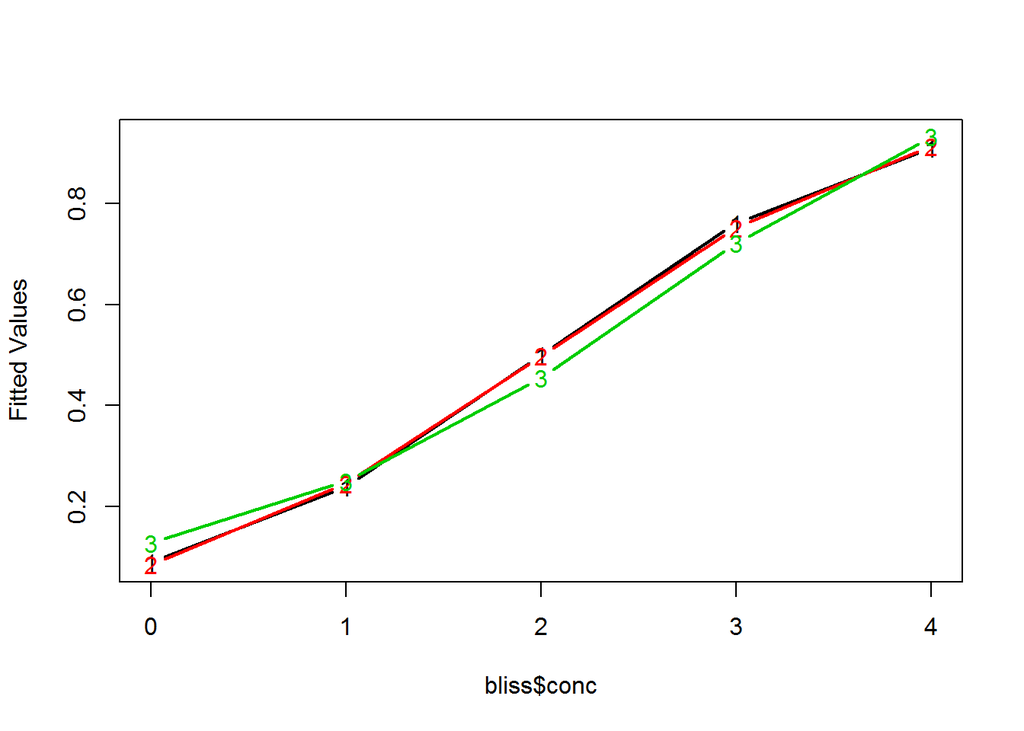

```r
matplot(bliss$conc,cbind(fitted(modl),fitted(modp),fitted(modc)),type="b",lty=1,lwd=2,ylab="Fitted Values")
```

They are similar.

Now look at the wider range.

```r
x<-seq(-2,8,.2)
```

For logit:

```r
pl<-ilogit(modl$coef[1]+modl$coef[2]*x)
```

For probit:

```r
pp<-pnorm(modp$coef[1]+modp$coef[2]*x)
```

And for complimentary log-log:

```r
pc<-1-exp(-exp((modc$coef[1]+modc$coef[2]*x)))
```

Plot all 3 curves

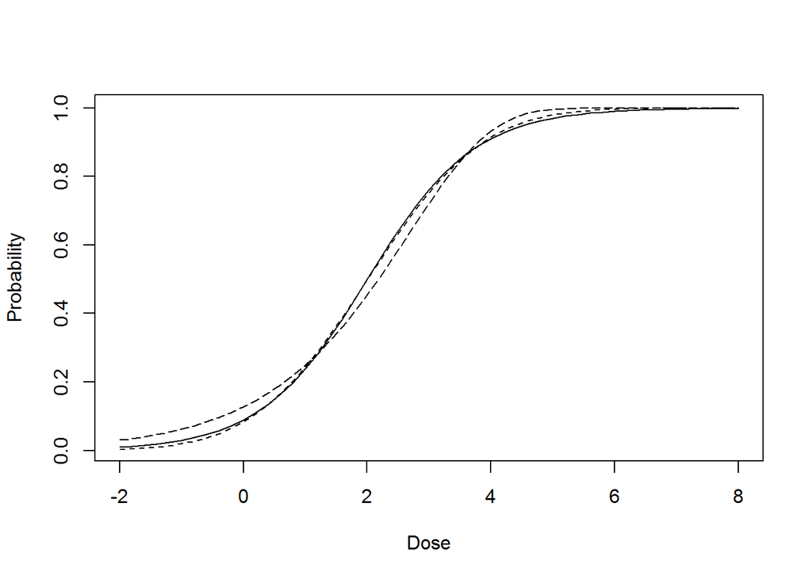

```r
plot(x,pl,type="l",ylab="Probability",xlab="Dose")
lines(x,pp,lty=2)
lines(x,pc,lty=5)
```

To distinguish the lines better plot their relative differences.

First show the ratio of probit to logit links probabilities: solid line - lower tail; dashed line - upper tail.

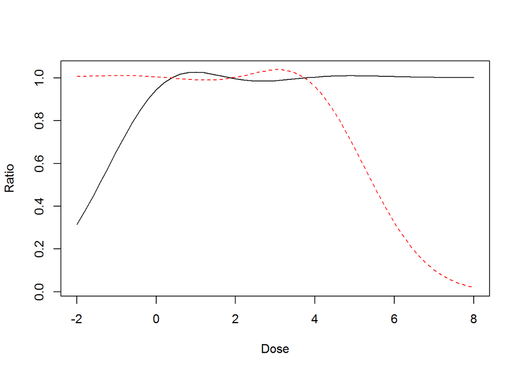

```r
matplot(x,cbind(pp/pl,(1-pp)/(1-pl)),type="l",xlab="Dose",ylab="Ratio")
```

Then the same plot for the ratio of complimentary log-log to logit links.

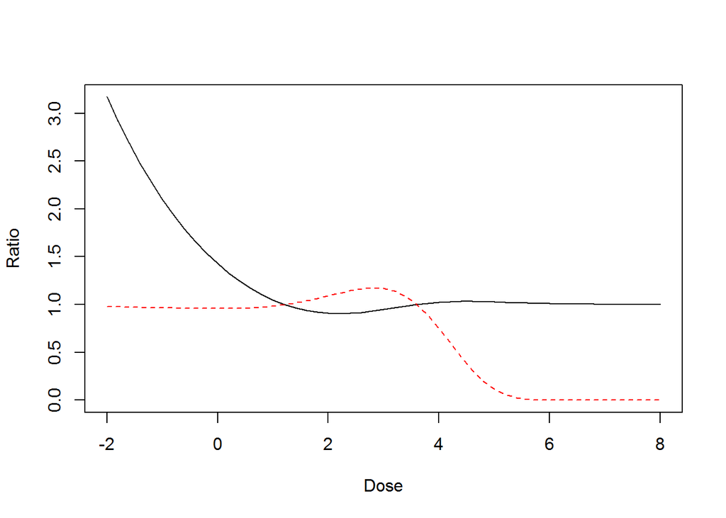

```r
matplot(x,cbind(pc/pl,(1-pc)/(1-pl)),type="l",xlab="Dose",ylab="Ratio")
```

On both relative differences plots we see that for the range of the data from 0 to 4 the differences are not significant.

However, if we go to the tails the differences become significant.  
This is important in cases when we need to analyze tail effects.  
For example, it is easy to collect data and analyze the amount of harm caused by a more significant concentrations of toxic substances.  
But drawing conclusions for the effects of low concentrations (small $p$) is much more difficult. Any studies based on high concentration levels do not provide information on this case.

## 4.3 Calculate Pearson Residuals and Compare with Deviance

Pearson residual statistic for binomial distribution is based on residuals:

$$r_i^P=\frac{(y_i - n_i p_i)}{n_i p_i (1-p_i)},$$
where $y_i$ is the number of successes, $n_i p_i$ is its expected value and $n_i p_i (1-p_i)$ is its variance.

The sum of squares of Pearson residuals is the Pearson goodness of fit statistic.

Usually this sum of squares and deviance are close to each other.

```r
modl<-glm(cbind(dead,alive)~conc,family=binomial,data=bliss)
sum(residuals(modl,type="pearson")^2)
```

```
## [1] 0.3672674
```

```r
deviance(modl)
```

```
## [1] 0.3787483
```

# 5 Comparison of Logit and Probit Regressions and Interpretation of Parameters

Both logit and probit regressions are internally based on linear models:

- For logit

  $$\ln(\frac{p}{1-p})=\beta_0 + \beta_1 x + \epsilon,$$
- For probit

  $$\Phi^{-1}(p)=\beta_0 + \beta_1 x + \epsilon.$$

The difference is in assumptions about $\epsilon$.

- For logit - standard logistic distribution

  $$\epsilon \sim Logis,$$
- For probit - standard normal distribution

  $$\epsilon \sim \Phi.$$

See difference between the two assumptions.

For densities:

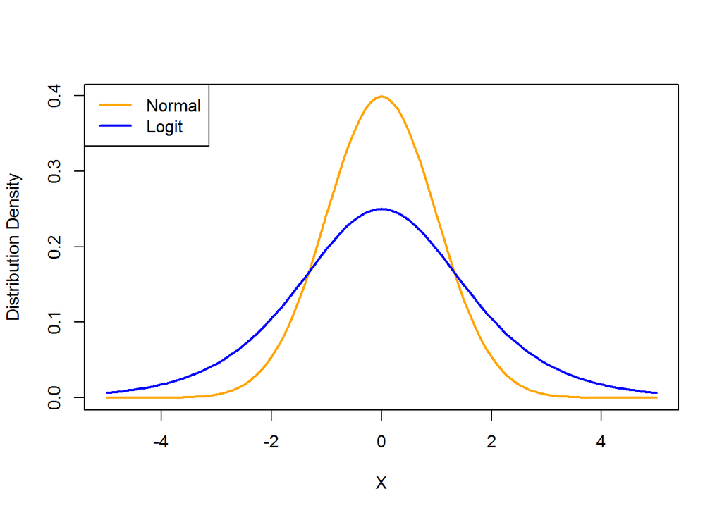

```r
X<-seq(from=-5,to=5,by=.1)
plot(X,dnorm(X),type="l",col="orange",lwd=2,ylab="Distribution Density")
lines(X,dlogis(X),type="l",col="blue",lwd=2)
legend("topleft",legend=c("Normal","Logit"),col=c("orange","blue"),lwd=2)
```

And for cumulative distribution functions:

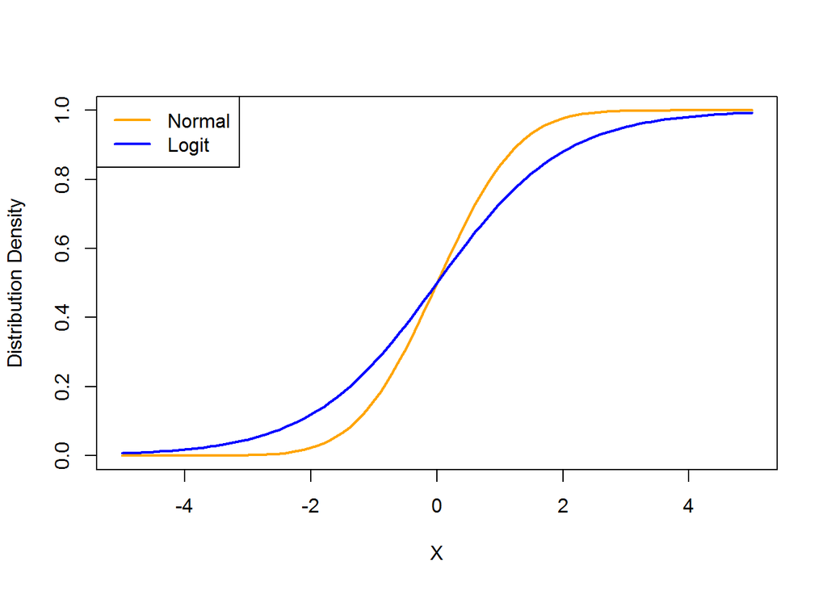

```r
plot(X,pnorm(X),type="l",col="orange",lwd=2,ylab="Distribution Density")
lines(X,plogis(X),type="l",col="blue",lwd=2)
legend("topleft",legend=c("Normal","Logit"),col=c("orange","blue"),lwd=2)
```

## 5.1 Example 1

The following data are from library `HSAUR` and has the description in the help file.

A sex difference in the age of onset of schizophrenia was noted by Kraepelin:  
**E. Kraepelin (1919), Dementia Praecox and Paraphrenia. Livingstone, Edinburgh**.

Subsequently epidemiological studies of the disorder have consistently shown an earlier onset in men than in women.  
One model that has been suggested to explain this observed difference is known as the sub-type model which postulates two types of schizophrenia:

- One characterized by early onset, typical symptoms and poor premorbid (prior to diagnosis) competence;
- And the other by late onset, atypical symptoms, and good premorbid competence.

The early onset type is assumed to be largely a disorder of men and the late onset largely a disorder of women.

```r
suppressWarnings(library(HSAUR))
```

```r
head(schizophrenia)
```

```
##   age gender
## 1  20 female
## 2  30 female
## 3  21 female
## 4  23 female
## 5  30 female
## 6  25 female
```

Add column of index of female participants for convenience.  
Fit both logit and probit binomial regression models with sex as response and age of onset as predictor.

```r
schizophrenia$idxF<-schizophrenia$gender=="female"
logitSchi<-glm(idxF~age,family=binomial,data=schizophrenia)
probitSchi<-glm(idxF~age,family=binomial(link="probit"),data=schizophrenia)
summary(logitSchi)
```

```
##
## Call:
## glm(formula = idxF ~ age, family = binomial, data = schizophrenia)
##
## Deviance Residuals:
##     Min       1Q   Median       3Q      Max
## -1.8747  -0.9069  -0.7711   1.2474   1.9615
##
## Coefficients:
##             Estimate Std. Error z value Pr(>|z|)
## (Intercept) -2.15054    0.39858  -5.396 6.83e-08 ***
## age          0.06411    0.01395   4.597 4.29e-06 ***
## ---
## Signif. codes:  0 '***' 0.001 '**' 0.01 '*' 0.05 '.' 0.1 ' ' 1
##
## (Dispersion parameter for binomial family taken to be 1)
##
##     Null deviance: 336.68  on 250  degrees of freedom
## Residual deviance: 312.46  on 249  degrees of freedom
## AIC: 316.46
##
## Number of Fisher Scoring iterations: 4
```

```r
summary(probitSchi)
```

```
##
## Call:
## glm(formula = idxF ~ age, family = binomial(link = "probit"),
##     data = schizophrenia)
##
## Deviance Residuals:
##     Min       1Q   Median       3Q      Max
## -1.8841  -0.9093  -0.7714   1.2477   1.9851
##
## Coefficients:
##              Estimate Std. Error z value Pr(>|z|)
## (Intercept) -1.318221   0.235976  -5.586 2.32e-08 ***
## age          0.039214   0.008272   4.740 2.13e-06 ***
## ---
## Signif. codes:  0 '***' 0.001 '**' 0.01 '*' 0.05 '.' 0.1 ' ' 1
##
## (Dispersion parameter for binomial family taken to be 1)
##
##     Null deviance: 336.68  on 250  degrees of freedom
## Residual deviance: 312.51  on 249  degrees of freedom
## AIC: 316.51
##
## Number of Fisher Scoring iterations: 4
```

Both models have similar deviance and AIC measures, but coefficients are very different.

### 5.1.1 Interpretation of probit coefficients

Predict probability of female using both models and plot the results.

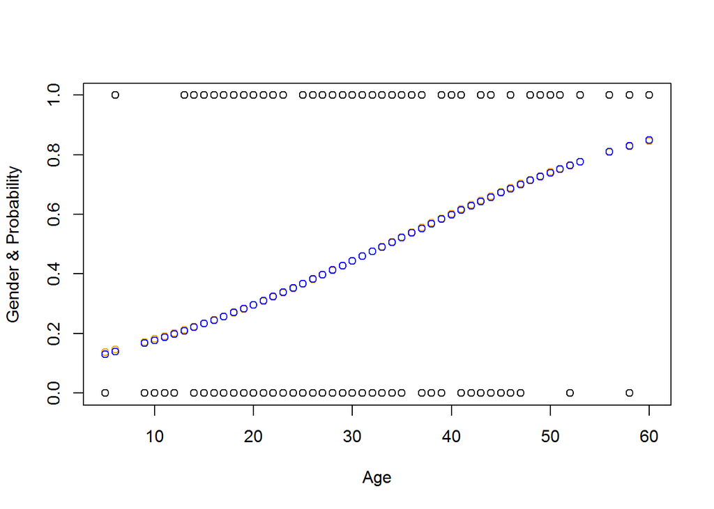

```r
predictF.logit<-predict(logitSchi,type="response")
predictF.probit<-predict(probitSchi,type="response")

plot(schizophrenia$age,schizophrenia$idxF,xlab="Age",ylab="Gender & Probability")
points(schizophrenia$age,predictF.logit,col="orange")
points(schizophrenia$age,predictF.probit,col="blue")
```

There is practically no difference between the predicted probabilities of the two models.  
The model shows steady increase with age of probability that diagnosed patient is female.

Check how probabilities can be obtained using coefficients of each model.

Predicted probability of diagnosing female at age 30:

- By logit

```r
predict(logitSchi,type="response",newdata=data.frame(age=30))
```

```
##         1
## 0.4434391
```

- By manual calculation with logit

```r
logCoeff<-logitSchi$coefficients
plogis(logCoeff%*%c(1,30))
```

```
##           [,1]
## [1,] 0.4434391
```

```r
exp(logCoeff%*%c(1,30))/(1+exp(logCoeff%*%c(1,30)))
```

```
##           [,1]
## [1,] 0.4434391
```

- By probit

```r
predict(probitSchi,type="response",newdata=data.frame(age=30))
```

```
##         1
## 0.4436152
```

By manual calculation using probit

```r
proCoeff<-probitSchi$coefficients
pnorm(proCoeff%*%c(1,30))
```

```
##           [,1]
## [1,] 0.4436152
```

Now it is clear that such different coefficients of the probit and logit fits still result in very similar predicted probabilities.

## 5.2 Example 2

Data `womensrole` are from a survey from 1974/1975 asking both female and male responders about their opinion on the statement:  
**Women should take care of running their homes and leave running the country up to men**.

The data are from  
**S.J. Haberman (1973), The analysis of residuals in cross-classificed tables. Biometrics, 29, 205–220**.

Data are also available from library `HSAUR`.

Variables of the data frame:

- `education` years of education;
- `sex` a factor with levels “Male” and “Female”;
- `agree` number of subjects in agreement with the statement;
- `disagree` number of subjects in disagreement with the statement.

```r
head(womensrole)
```

```
##   education  sex agree disagree
## 1         0 Male     4        2
## 2         1 Male     2        0
## 3         2 Male     4        0
## 4         3 Male     6        3
## 5         4 Male     5        5
## 6         5 Male    13        7
```

```r
summary(subset(womensrole, sex == "Female"))
```

```
##    education      sex         agree           disagree
##  Min.   : 0   Male  : 0   Min.   :  0.00   Min.   :  0.00
##  1st Qu.: 5   Female:21   1st Qu.:  3.00   1st Qu.:  2.00
##  Median :10               Median : 13.00   Median : 21.00
##  Mean   :10               Mean   : 26.43   Mean   : 48.14
##  3rd Qu.:15               3rd Qu.: 26.00   3rd Qu.: 62.00
##  Max.   :20               Max.   :190.00   Max.   :403.00
```

```r
summary(subset(womensrole, sex == "Male"))
```

```
##    education      sex         agree           disagree
##  Min.   : 0   Male  :21   Min.   :  1.00   Min.   :  0
##  1st Qu.: 5   Female: 0   1st Qu.:  4.00   1st Qu.:  7
##  Median :10               Median : 13.00   Median : 23
##  Mean   :10               Mean   : 22.14   Mean   : 40
##  3rd Qu.:15               3rd Qu.: 29.00   3rd Qu.: 49
##  Max.   :20               Max.   :115.00   Max.   :245
```

Fit Logit and probit regression models

```r
glmLogit<-glm(cbind(agree,disagree)~education+sex,family=binomial,data=womensrole)
glmProbit<-glm(cbind(agree,disagree)~education+sex,family=binomial(link="probit"),data=womensrole)
summary(glmLogit)
```

```
##
## Call:
## glm(formula = cbind(agree, disagree) ~ education + sex, family = binomial,
##     data = womensrole)
##
## Deviance Residuals:
##      Min        1Q    Median        3Q       Max
## -2.72544  -0.86302  -0.06525   0.84340   3.13315
##
## Coefficients:
##             Estimate Std. Error z value Pr(>|z|)
## (Intercept)  2.50937    0.18389  13.646   <2e-16 ***
## education   -0.27062    0.01541 -17.560   <2e-16 ***
## sexFemale   -0.01145    0.08415  -0.136    0.892
## ---
## Signif. codes:  0 '***' 0.001 '**' 0.01 '*' 0.05 '.' 0.1 ' ' 1
##
## (Dispersion parameter for binomial family taken to be 1)
##
##     Null deviance: 451.722  on 40  degrees of freedom
## Residual deviance:  64.007  on 38  degrees of freedom
## AIC: 208.07
##
## Number of Fisher Scoring iterations: 4
```

```r
summary(glmProbit)
```

```
##
## Call:
## glm(formula = cbind(agree, disagree) ~ education + sex, family = binomial(link = "probit"),
##     data = womensrole)
##
## Deviance Residuals:
##    Min      1Q  Median      3Q     Max
## -2.804  -0.803  -0.099   0.819   3.354
##
## Coefficients:
##              Estimate Std. Error z value Pr(>|z|)
## (Intercept)  1.476419   0.106880  13.814   <2e-16 ***
## education   -0.160059   0.008782 -18.226   <2e-16 ***
## sexFemale   -0.012982   0.050482  -0.257    0.797
## ---
## Signif. codes:  0 '***' 0.001 '**' 0.01 '*' 0.05 '.' 0.1 ' ' 1
##
## (Dispersion parameter for binomial family taken to be 1)
##
##     Null deviance: 451.722  on 40  degrees of freedom
## Residual deviance:  66.976  on 38  degrees of freedom
## AIC: 211.04
##
## Number of Fisher Scoring iterations: 4
```

Again both models show approximately same quality of fit, but very different parameters.  
Education seems to be a significant factor, but gender - not.

Predict probabilities of agreement with the statement by each of the models.

```r
predLogit<-predict(glmLogit,type="response")
predProbit<-predict(glmProbit,type="response")
idxF<-womensrole$sex=="Female"
```

Plot probabilities of agreement by both models as functions education.

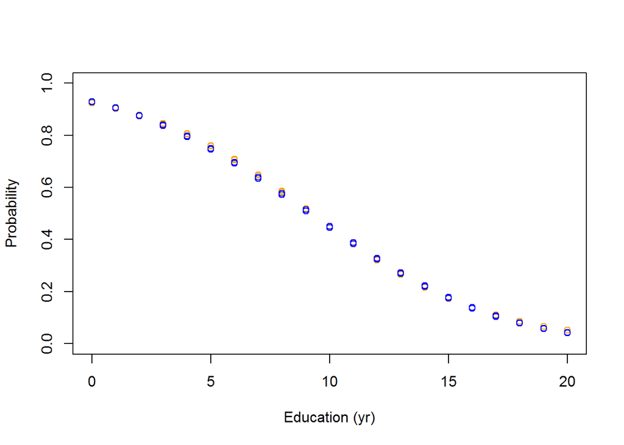

```r
plot(womensrole$education,predLogit,xlim=range(womensrole$education),
     ylim=c(0,1),col="orange",type="p",
     xlab="Education (yr)",ylab="Probability")
lines(womensrole$education,predProbit,col="blue",type="p")
```

There is practically no difference between predictions by the two models.

Check how predicted probabilities differ by gender.

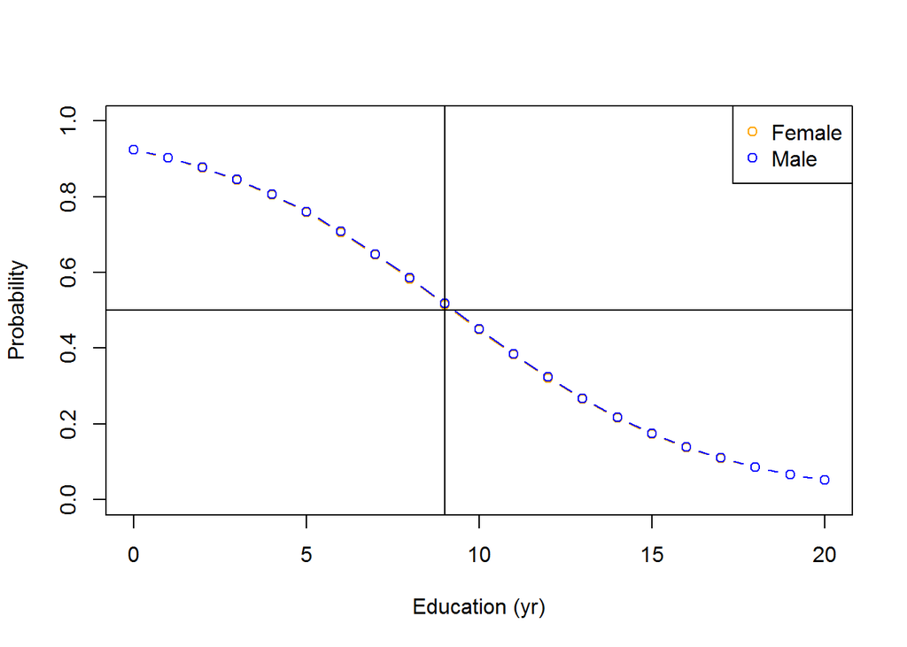

```r
plot(womensrole$education[idxF],predLogit[idxF],
     xlim=range(womensrole$education),ylim=c(0,1),col="orange",type="b",
     xlab="Education (yr)",ylab="Probability")
lines(womensrole$education[!idxF],predLogit[!idxF],col="blue",type="b")
abline(h=.5)
abline(v=9)
legend("topright",legend=c("Female","Male"),col=c("orange","blue"),pch=1)
```

Probability of agreement drops below 50% after 9 years of education.